# Simple Recommendation Systems: Item-based Collaborative Filtering

& Lots of Pandas :)

In this notebook, we will walk through a simple item-based collaborative filtering system for movie recommendation. The metric for similarity score between movies is cosine similarity.

Let's get started by importing some library and our dataset. Have a look at this link to know more about the dataset.

Dataset : https://grouplens.org/datasets/movielens/latest/

http://files.grouplens.org/datasets/movielens/ml-latest-small-README.html

Link to read more about this method:

https://medium.com/@cfpinela/recommender-systems-user-based-and-item-based-collaborative-filtering-5d5f375a127f

```python
import pandas as pd
import numpy as np
import math
from IPython.display import Image
import warnings
warnings.filterwarnings("ignore")
```

```python
ratings = pd.read_csv("../resource/asnlib/publicdata/datasets/ratings.csv", encoding='"ISO-8859-1"')
movies = pd.read_csv("../resource/asnlib/publicdata/datasets/movies.csv", encoding='"ISO-8859-1"')

# We only used a subset of the dataset (constraint t_1)
subset_mode = True
t_1 = 100

if subset_mode:
    ratings = ratings[(ratings['movieId'] < t_1) & (ratings['userId'] < t_1)]
    movies = movies[movies['movieId'].isin(ratings.movieId.unique())]
```

```python
ratings.head()
```

|  | userId | movieId | rating | timestamp |
| --- | --- | --- | --- | --- |
| 0 | 1 | 31 | 2.5 | 1260759144 |
| 20 | 2 | 10 | 4.0 | 835355493 |
| 21 | 2 | 17 | 5.0 | 835355681 |
| 22 | 2 | 39 | 5.0 | 835355604 |
| 23 | 2 | 47 | 4.0 | 835355552 |

```python
movies.head()
```

|  | movieId | title | genres |
| --- | --- | --- | --- |
| 0 | 1 | Toy Story (1995) | Adventure\|Animation\|Children\|Comedy\|Fantasy |
| 1 | 2 | Jumanji (1995) | Adventure\|Children\|Fantasy |
| 2 | 3 | Grumpier Old Men (1995) | Comedy\|Romance |
| 3 | 4 | Waiting to Exhale (1995) | Comedy\|Drama\|Romance |
| 4 | 5 | Father of the Bride Part II (1995) | Comedy |

```python
print("There are : {} ratings for {} movies".format(len(ratings),len(movies)))
full_ratings = ratings.merge(movies, on ="movieId",how="left")[["userId","movieId", "rating","title","genres"]]
print(len(full_ratings))
full_ratings.head()
```

```
There are : 573 ratings for 75 movies
573
```

|  | userId | movieId | rating | title | genres |
| --- | --- | --- | --- | --- | --- |
| 0 | 1 | 31 | 2.5 | Dangerous Minds (1995) | Drama |
| 1 | 2 | 10 | 4.0 | GoldenEye (1995) | Action\|Adventure\|Thriller |
| 2 | 2 | 17 | 5.0 | Sense and Sensibility (1995) | Drama\|Romance |
| 3 | 2 | 39 | 5.0 | Clueless (1995) | Comedy\|Romance |
| 4 | 2 | 47 | 4.0 | Seven (a.k.a. Se7en) (1995) | Mystery\|Thriller |

```python
# Code for comparing pandas dataframes. You should recognize this!

def canonicalize_tibble(X):
    var_names = sorted(X.columns)
    Y = X[var_names].copy()
    Y.sort_values(by=var_names, inplace=True)
    Y.reset_index(drop=True, inplace=True)
    return Y

def tibbles_are_equivalent (A, B):
    A_canonical = canonicalize_tibble(A)
    B_canonical = canonicalize_tibble(B)
    cmp = A_canonical.eq(B_canonical)
    return cmp.all().all()
```

### Excercise 1 (1 points)

In this exercise, you will compute the mean rating and adjusted rating for each movie by a particular user. Then final result will be a table named "adjusted_ratings" with these columns: userId, movieId, rating, title, genres, rating_mean, rating_adjusted.

For example:

[output not shown]

### Your task:

```
1. From full_ratings table, calculate rating mean for each movie
2. Then, calculate rating_adjusted for each pair of (user_j & movie_i) in full_ratings table.
3. For the pairs that have rating_adjusted == 0, replace that value with 1e-6 to avoid 0 denominator in future operations.
4. Return adjusted_ratings table with these columns: userId, movieId, rating, title, genres, rating_mean, rating_adjusted
```

```
Sample of the expected output: (Frist 5 lines of adjusted_ratings table)
```

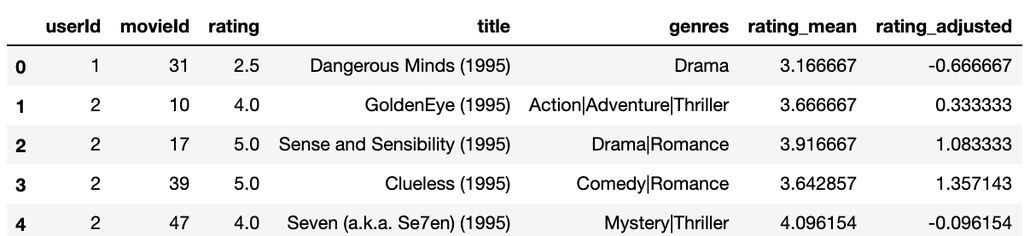

```python
print("Sample of the expected output: (Frist 5 lines of adjusted_ratings table) ")

Image(filename='../resource/asnlib/publicdata/Ex1.png')
```

```python
# Remember to replace 0 adjusted rating values to 1*e-6 in order to avoid 0 denominator

# Create dataframe that is a copy of full_ratings df
adjusted_ratings = full_ratings.copy()

# Calculate the mean rating for each movie (using the `full_ratings` table)
from collections import defaultdict

avgrating_by_movie = defaultdict(float)

for i in range(len(full_ratings)):
    movie_id = full_ratings.loc[i, 'movieId']
    sub_df = full_ratings[full_ratings['movieId'] == movie_id]
    avgrating_by_movie[movie_id] = sub_df['rating'].mean()

avg_rating_l = [avgrating_by_movie[movie] for movie in adjusted_ratings['movieId']]
assert len(avg_rating_l) == len(adjusted_ratings)
adjusted_ratings['rating_mean'] = avg_rating_l


# Calculate adjusted ratings by each user
# Adjusted rating = (mean rating per movie) *minus* (user rating)
rating_adj_l = [(user - avg) for avg, user in zip(adjusted_ratings['rating_mean'], adjusted_ratings['rating'])]
adjusted_ratings['rating_adjusted'] = rating_adj_l
adjusted_ratings['rating_adjusted'].replace(0, 1e-6, inplace=True)

###

adjusted_ratings.head()
```

|  | userId | movieId | rating | title | genres | rating_mean | rating_adjusted |
| --- | --- | --- | --- | --- | --- | --- | --- |
| 0 | 1 | 31 | 2.5 | Dangerous Minds (1995) | Drama | 3.166667 | -0.666667 |
| 1 | 2 | 10 | 4.0 | GoldenEye (1995) | Action\|Adventure\|Thriller | 3.666667 | 0.333333 |
| 2 | 2 | 17 | 5.0 | Sense and Sensibility (1995) | Drama\|Romance | 3.916667 | 1.083333 |
| 3 | 2 | 39 | 5.0 | Clueless (1995) | Comedy\|Romance | 3.642857 | 1.357143 |
| 4 | 2 | 47 | 4.0 | Seven (a.k.a. Se7en) (1995) | Mystery\|Thriller | 4.096154 | -0.096154 |

```python
#TEST CELL 1: adjusted_ratings test
csv_rounding_error_places = 5

assert all(adjusted_ratings.rating_adjusted != 0), "Remember to replace 0 adjusted rating values to 1*e-6 in order to avoid 0 denominator"
adjusted_ratings_sol = pd.read_csv('../resource/asnlib/publicdata/adjusted_ratings_sol.csv')
adjusted_ratings_sol.rating_mean = adjusted_ratings_sol.rating_mean.round(csv_rounding_error_places)
adjusted_ratings_sol.rating_adjusted = adjusted_ratings_sol.rating_adjusted.round(csv_rounding_error_places)

adjusted_ratings_rounded = adjusted_ratings.copy()
adjusted_ratings_rounded.rating_mean = adjusted_ratings_rounded.rating_mean.round(csv_rounding_error_places)
adjusted_ratings_rounded.rating_adjusted = adjusted_ratings_rounded.rating_adjusted.round(csv_rounding_error_places)

assert tibbles_are_equivalent(adjusted_ratings_sol,adjusted_ratings_rounded)

print("\n(Passed!)")
```

```
(Passed!)
```

### Exercise 2 (5 points total)

In this exercise, you will compute the item-to-item weight matrix, which represent how similar each movie is to other movies. There are 3 steps in this exercise.

#### Step 1: build_movie_i_matrix function (2 points)

From what we already have built above, your task is to build a new table to show interactions between movie i (rated by a subset of userId X) and other movies rated by subset userId X.

Interactions here are the adjusted rating of movie i (i is constant) and other movies (rated by user x), from the adjusted_rating tables.

Return a table with these columns: ['userId', 'movie_1', 'movie_2', 'rating_adjusted_1', 'rating_adjusted_2']

##### Note: in this function: column "movie_1" is a constant i = movieId

##### Please do not include the interaction of movie i to itself.

```
    For example:
        Movie i rated by users (A,B)
        uA rated movie i,j,k
        uB rated movie i,m,n,h
        => table return:
```

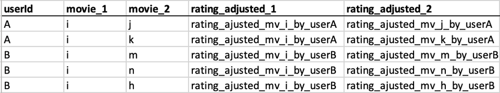

```python
print("""
    For example:
        Movie i rated by users (A,B)
        uA rated movie i,j,k
        uB rated movie i,m,n,h
        => table return: """)
Image(filename='../resource/asnlib/publicdata/step1_build_movie_i_matrix.png')
```

```python
def build_movie_i_matrix(movie_i):
    # Columns used in the output format
    used_cols = ['userId', 'movie_1', 'movie_2', 'rating_adjusted_1', 'rating_adjusted_2']

    # Subset userId A rated movie i
    distinct_users = np.unique(adjusted_ratings[adjusted_ratings['movieId'] == movie_i].userId)

    movie_i_table = []

    # Build the table described above and name it movie_i_table
    # Iterate over the distinct users to see how many other movies they watched
    for user in distinct_users:
        mini_df = pd.DataFrame()
        sub_df = adjusted_ratings[adjusted_ratings['userId'] == user]

        if len(sub_df) == 1:    # the user only watched 1 movie
            pass
        else:
            mini_df = sub_df[sub_df['movieId'] != movie_i]
            mini_df['movie_1'] = movie_i
            mini_df['rating_adjusted_1'] = float(sub_df[sub_df['movieId'] == movie_i]['rating_adjusted'])
            mini_df.rename(columns={'movieId':'movie_2',
                                   'rating_adjusted':'rating_adjusted_2'},
                           inplace=True)

        movie_i_table.append(mini_df)

    ###
    movie_i_table = pd.concat(movie_i_table)
    movie_i_table.reset_index(drop=True, inplace=True)

    return movie_i_table[used_cols]
```

```python
build_movie_i_matrix(31).head()
```

|  | userId | movie_1 | movie_2 | rating_adjusted_1 | rating_adjusted_2 |
| --- | --- | --- | --- | --- | --- |
| 0 | 7 | 31 | 1 | -0.166667 | -0.824324 |
| 1 | 7 | 31 | 10 | -0.166667 | -0.666667 |
| 2 | 7 | 31 | 21 | -0.166667 | -0.456522 |
| 3 | 7 | 31 | 34 | -0.166667 | 0.204545 |
| 4 | 7 | 31 | 40 | -0.166667 | 0.000001 |

```python
#TEST CELL 2: Ex 2, step 1:
csv_rounding_error_places = 3

m1_matrix = build_movie_i_matrix(movie_i=1)
m1_matrix_rounded = m1_matrix.copy()
m1_matrix_rounded.rating_adjusted_1 = m1_matrix_rounded.rating_adjusted_1.round(csv_rounding_error_places)
m1_matrix_rounded.rating_adjusted_2 = m1_matrix_rounded.rating_adjusted_2.round(csv_rounding_error_places)

Ex2s1_sol = pd.read_csv('../resource/asnlib/publicdata/m1_matrix_sol.csv')
Ex2s1_sol = Ex2s1_sol[list(m1_matrix.columns)]
Ex2s1_sol.rating_adjusted_1 = Ex2s1_sol.rating_adjusted_1.round(csv_rounding_error_places)
Ex2s1_sol.rating_adjusted_2 = Ex2s1_sol.rating_adjusted_2.round(csv_rounding_error_places)

assert tibbles_are_equivalent(Ex2s1_sol,m1_matrix_rounded)

print("\n(Passed!)")
```

```
(Passed!)
```

#### Step 2: Calculate cosine similarity metric (1 points)

From the build_movie_i_matrix function on Step 1, we have a table that shows interaction between movie i and other movies.

#### Your Task: Build function similarity_score to calculate the similarity score, which shows how similar movie i is to movie j

#### You need to implement this by hand, do not use any imported package/method to calculate the score. Otherwise, you will receive 0 point for Ex2.Step2

Let's look at the formula of cosine metric below.

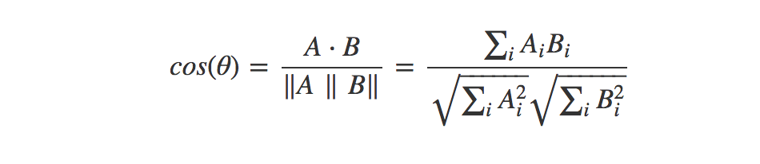

```python
Image(filename='../resource/asnlib/publicdata/cosine_score.png')
```

```
A is rating_adjusted_1, B is rating_adjusted_2
cos(theta) is the similarity score of movieId=1 to movieId=2
```

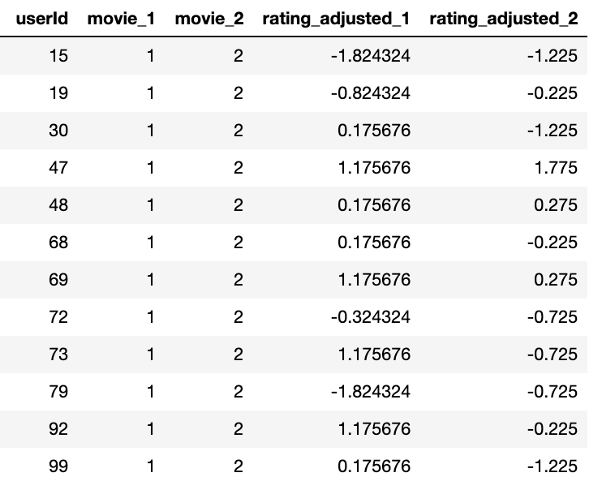

```python
# Suppose we have a table like this (extract from step 1):

print( """A is rating_adjusted_1, B is rating_adjusted_2
cos(theta) is the similarity score of movieId=1 to movieId=2""")
Image(filename='../resource/asnlib/publicdata/cosine_table_1.png')
```

```python
my_m_i_matrix = build_movie_i_matrix(31)
display(my_m_i_matrix.head(3))

my_m_i_matrix[my_m_i_matrix['movie_2'] == 1]
```

|  | userId | movie_1 | movie_2 | rating_adjusted_1 | rating_adjusted_2 |
| --- | --- | --- | --- | --- | --- |
| 0 | 7 | 31 | 1 | -0.166667 | -0.824324 |
| 1 | 7 | 31 | 10 | -0.166667 | -0.666667 |
| 2 | 7 | 31 | 21 | -0.166667 | -0.456522 |

|  | userId | movie_1 | movie_2 | rating_adjusted_1 | rating_adjusted_2 |
| --- | --- | --- | --- | --- | --- |
| 0 | 7 | 31 | 1 | -0.166667 | -0.824324 |
| 36 | 73 | 31 | 1 | 0.333333 | 1.175676 |

```python
def similarity_score(m_i_matrix, movie_2):
    m1_m2_matrix = m_i_matrix[m_i_matrix['movie_2'] == movie_2]

    ###
    A = m1_m2_matrix['rating_adjusted_1'].tolist()
    B = m1_m2_matrix['rating_adjusted_2'].tolist()

    Ai_x_Bi = np.multiply(A, B)
    Sigma_AB = np.sum(Ai_x_Bi)
    Ai_norm = np.sqrt(np.sum([ra1**2 for ra1 in A]))
    Bi_norm = np.sqrt(np.sum([ra2**2 for ra2 in B]))

    similar_score = Sigma_AB / (Ai_norm * Bi_norm)
    ###

    return similar_score
```

```python
#TEST CELL Exercise 2, Step 2: similarity_score
mi = build_movie_i_matrix(movie_i=1)
r = 5
print("Test case for movie 1 vs other:\n")
print("Similarity (weight) score of movie 1 & 70 is: {}".format(round(similarity_score(mi,70),r)))
assert round(similarity_score(mi,70), r) == round(0.6133707825231072, r)
print("\nSimilarity (weight) score of movie 1 & 6 is: {}".format(round(similarity_score(mi,6),r)))
assert round(similarity_score(mi,6), r) == round(-0.17628755506552993, r)
print("\nSimilarity (weight) score of movie 1 & 2 is: {}".format(round(similarity_score(mi,2),r)))
assert round(similarity_score(mi,2), r) == round(0.4340934664094167, r)
print("\nPassed")
```

```
Test case for movie 1 vs other:

Similarity (weight) score of movie 1 & 70 is: 0.61337

Similarity (weight) score of movie 1 & 6 is: -0.17629

Similarity (weight) score of movie 1 & 2 is: 0.43409

Passed
```

#### Step 3: (2 points)

#### Your Task: Build a weight matrix table that shows the similarity score between movies

Notes: do not include the score of that movie to itself

Have a look at our sample table below.

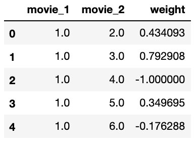

```python
Image(filename='../resource/asnlib/publicdata/w_matrix_sample.png')
```

```python
test_movies = adjusted_ratings.movieId.unique().tolist()
my_movies = test_movies.copy()
my_movies.remove(31)
len(my_movies) == len(movies)-1
```

```
True
```

```python
my_mi_matrix = build_movie_i_matrix(31)
my_mi_matrix.head()
```

|  | userId | movie_1 | movie_2 | rating_adjusted_1 | rating_adjusted_2 |
| --- | --- | --- | --- | --- | --- |
| 0 | 7 | 31 | 1 | -0.166667 | -0.824324 |
| 1 | 7 | 31 | 10 | -0.166667 | -0.666667 |
| 2 | 7 | 31 | 21 | -0.166667 | -0.456522 |
| 3 | 7 | 31 | 34 | -0.166667 | 0.204545 |
| 4 | 7 | 31 | 40 | -0.166667 | 0.000001 |

```python
weights = []
for mv in my_mi_matrix['movie_2'].tolist():
    weights.append(similarity_score(my_mi_matrix, mv))
len(weights) == len(my_mi_matrix)
```

```
True
```

```python
# function of building the item-to-item weight matrix
def create_weight_matrix(adjusted_ratings):
    # define weight matrix
    matrix_cols = ['movie_1', 'movie_2', 'weight']
    w_matrix = pd.DataFrame(columns = matrix_cols)

    # list all distinct movies in dataset
    distinct_mv = adjusted_ratings.movieId.unique().tolist()

    # Loop through all movies and apply the functions we built above to build a matrix show similarity score of movies
    # Hint: You might need more than 1 loop ;)

    ###
    for mv in distinct_mv:
        mini_dfs = pd.DataFrame()

        mv_i_matrix = build_movie_i_matrix(mv)
        mini_dfs['movie_1'] = mv_i_matrix['movie_1']
        mini_dfs['movie_2'] = mv_i_matrix['movie_2']

        weights = []
        for other_mv in mv_i_matrix['movie_2'].tolist():
            weights.append(similarity_score(mv_i_matrix, other_mv))
        mini_dfs['weight']  = weights

        w_matrix = pd.concat([w_matrix, mini_dfs])

    ###
    w_matrix.drop_duplicates(subset=['movie_1', 'movie_2'], inplace=True)

    return w_matrix

w_matrix = create_weight_matrix(adjusted_ratings)
w_matrix.head()
```

|  | movie_1 | movie_2 | weight |
| --- | --- | --- | --- |
| 0 | 31 | 1 | 0.989090 |
| 1 | 31 | 10 | -0.500000 |
| 2 | 31 | 21 | 0.629911 |
| 3 | 31 | 34 | -0.953231 |
| 4 | 31 | 40 | -1.000000 |

```python
# Test cell 4: w_matrix
assert len(w_matrix) == 3396
csv_rounding_error_places = 3

Ex2s3_sol = pd.read_csv('../resource/asnlib/publicdata/w_matrix_cell_4_sol.csv')
Ex2s3_sol.weight = Ex2s3_sol.weight.round(csv_rounding_error_places)

w_matrix_rounded = w_matrix.copy()
w_matrix_rounded.weight = w_matrix_rounded.weight.round(csv_rounding_error_places)

assert tibbles_are_equivalent(w_matrix_rounded, Ex2s3_sol)
print("\n(Passed!)")
```

```
(Passed!)
```

### Exercise 3: Predict Rating (2 points)

#### Your Task: In case user u has never rated movie i, we want to build a function predict_rating that utilize w_matrix built above to output a predicted rating for movie i by user u. The formula and notation are below:

```
    s(i;u) = predicted rating of movie i by user u
    i = movie i
    M_i = mean rating of movie i
    u = user u
    Iu = Set of all movies rated by user u
    j = movies j that user u has rated
    r_uj = rating that user u gave to movie j
    Wij = weight/score between movie i & j (extracted from the weight matrix)
```

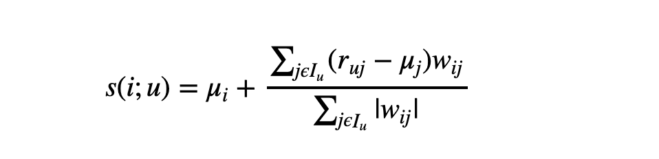

```python
Image(filename='../resource/asnlib/publicdata/predict_rating_formula_new.png')
```

```python
user_info = adjusted_ratings[adjusted_ratings['userId'] == 28]
user_info
```

|  | userId | movieId | rating | title | genres | rating_mean | rating_adjusted |
| --- | --- | --- | --- | --- | --- | --- | --- |
| 169 | 28 | 21 | 5.0 | Get Shorty (1995) | Comedy\|Crime\|Thriller | 3.456522 | 1.543478 |
| 170 | 28 | 58 | 5.0 | Postman, The (Postino, Il) (1994) | Comedy\|Drama\|Romance | 3.375000 | 1.625000 |

```python
def predict_rating(userId, movieId, w_matrix):

    # rating_mean for each movie
    rating_mean = full_ratings.groupby(['movieId'],
                                       as_index=False).mean().rename(columns={'rating': 'rating_mean'})[['movieId','rating_mean']]

    # set mean_rating = 2.5 if that movie has not been rated by any user.
    if rating_mean[rating_mean['movieId'] == movieId].shape[0] > 0:
        mean_rating = rating_mean[rating_mean['movieId'] == movieId]['rating_mean'].iloc[0]
    else:
        mean_rating = 2.5

    # Calculate predicted_rating for movieId by userId (based on w_matrix and formula given above)
    # Note: In case the denominator == 0 ( sum of absolute weight_ij == 0 ):
    # => s(i;u) = Mean_i ~ predicted_rating = mean_rating

    ###
    # get df where
    user_info = adjusted_ratings[adjusted_ratings['userId'] == userId]

    numerator_temp = []
    weights = []

    for movie, adj_rating in zip(user_info['movieId'], user_info['rating_adjusted']):
        weight = w_matrix[(w_matrix['movie_1']==movieId) & (w_matrix['movie_2'] == movie)]['weight']

        if weight.empty:
            numerator_temp.append(0)
            weights.append(0)
        else:
            numerator_temp.append(float(weight)*adj_rating)
            weights.append(float(weight))


    numerator = np.sum(numerator_temp)
    denominator = np.sum(np.abs(weights))

    if denominator == 0:
        denominator = mean_rating
    else:
        denominator

    predicted_rating = mean_rating + (numerator/denominator)
    ###

    return predicted_rating
```

```python
predict_rating(userId=28, movieId=8, w_matrix=w_matrix)
```

```
5.543478260869565
```

```python
# Test cell 5
r = 5
u = [28, 3, 85, 32, 43, 41, 72, 46, 49, 68]
m = [8, 21, 70, 58, 50, 20, 97, 81, 6, 65]
s = [5.543478260869565, 3.2565217391304344, 4.316658067627168, 2.9057416028855902, 4.6779544681179495, 1.525, 4.214855119542619, 3.2, 4.288262646823264, 3.130726141165826]
for u,m,s in list(zip(u,m,s)):
    score = predict_rating(u, m ,w_matrix)
    assert round(score,r) == round(s,r)

print("Passed")
```

```
Passed
```

### Exercise 4: Make Recommendation (2 point)

Now you have the powerful function "predict_rating" which can output a estimated score for any movie rated by an user.

Lets make recommendations!

#### Your Task: Define function "recommend" that produce top_n movies that have highest rating score.

Your output from recommend fucntion will look like this:

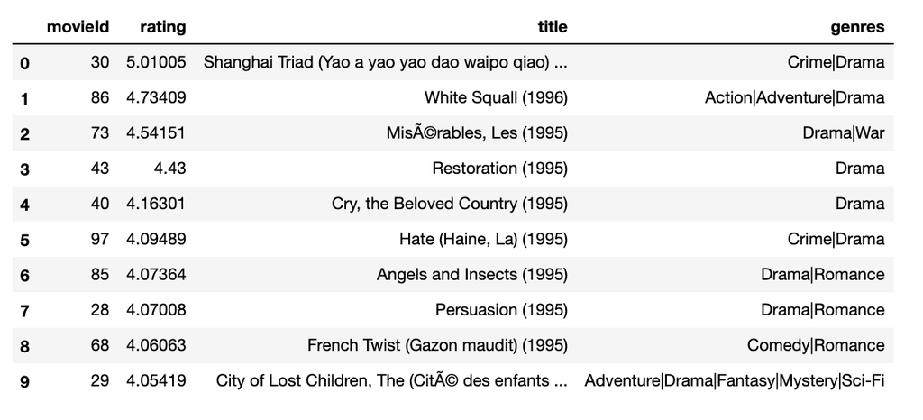

```python
Image(filename='../resource/asnlib/publicdata/Sample_ex4_sol_user15.png')
```

```python
seen = adjusted_ratings[adjusted_ratings['userId'] == 28]['movieId'].tolist()
print(len(seen))
print(seen)

movies[movies['movieId'].isin(seen)]
```

```
2
[21, 58]
```

|  | movieId | title | genres |
| --- | --- | --- | --- |
| 20 | 21 | Get Shorty (1995) | Comedy\|Crime\|Thriller |
| 54 | 58 | Postman, The (Postino, Il) (1994) | Comedy\|Drama\|Romance |

```python
def recommend(userId, w_matrix, adjusted_ratings, top_n=10):
    distinct_mv = adjusted_ratings['movieId'].unique()

    user_rating_full = pd.DataFrame(columns=['movieId', 'rating'])

    # Loop through all distinct_mv and calculate the ratings for all movies that the user hasn't rated
    # Store these predicted ratings to user_rating_full dataframe  (only not-yet-rated movies from user "userId")
    # Because we only want to recommend top_n movies with highest predicted ratings, that the user "userId" has not watched/rated.
    # We will show top_n items from your user_rating_full table to user as our recommendation

    ###
    user_seen_movies = adjusted_ratings[adjusted_ratings['userId'] == userId]['movieId'].tolist()
    unseen_movies = movies[~movies['movieId'].isin(user_seen_movies)]['movieId'].tolist()

    preds = []
    for unseen in unseen_movies:
        preds.append(predict_rating(userId, unseen, w_matrix))

    user_rating_full['movieId'] = unseen_movies
    user_rating_full['rating'] = preds

    ###
    # select top 10 movies rated by the user
    recommendations = user_rating_full.sort_values(by=['rating'], ascending=False).head(10)
    recommendations["movieId"] = recommendations["movieId"].astype("int64")
    recommendations = recommendations.merge(movies, on="movieId",how="left")

    return recommendations
```

```python
# Test Cell 6
# Get a recommendation list for a given user
csv_rounding_error_places = 3
user = [15,2,5]
fn_test = ["../resource/asnlib/publicdata/recommended_movies_u15_new.csv","../resource/asnlib/publicdata/recommended_movies_u2.csv","../resource/asnlib/publicdata/recommended_movies_u5.csv"]
for user, fn in list(zip(user,fn_test)):

    Ex4_sol = pd.read_csv(fn)
    Ex4_sol.rating = Ex4_sol.rating.round(csv_rounding_error_places)

    recommended_movies_pred = recommend(user, w_matrix, adjusted_ratings)
    recommended_movies_u2_rounded = recommended_movies_pred.copy()
    recommended_movies_u2_rounded.rating = recommended_movies_u2_rounded.rating.convert_objects(convert_numeric=True)
    recommended_movies_u2_rounded.rating = recommended_movies_u2_rounded.rating.round(csv_rounding_error_places)

    assert tibbles_are_equivalent(Ex4_sol, recommended_movies_u2_rounded)
    print("\n(Passed!)")
```

```
(Passed!)

(Passed!)

(Passed!)
```

**Fin!** You've reached the end of this problem. Don't forget to restart the kernel and run the entire notebook from top-to-bottom to make sure you did everything correctly. If that is working, try submitting this problem. (Recall that you must submit and pass the autograder to get credit for your work!)